# Reproducible Research: Peer Assessment 1

## Introduction

It is now possible to collect a large amount of data about personal movement using activity monitoring devices such as a [Fitbit](http://www.fitbit.com/), [Nike Fuelband](http://www.nike.com/us/en_us/c/nikeplus-fuelband), or [Jawbone Up](https://jawbone.com/up). These type of devices are part of the “quantified self” movement – a group of enthusiasts who take measurements about themselves regularly to improve their health, to find patterns in their behavior, or because they are tech geeks. But these data remain under-utilized both because the raw data are hard to obtain and there is a lack of statistical methods and software for processing and interpreting the data.

This assignment makes use of data from a personal activity monitoring device. This device collects data at 5 minute intervals through out the day. The data consists of two months of data from an anonymous individual collected during the months of October and November, 2012 and include the number of steps taken in 5 minute intervals each day.

## Data

The data for this assignment can be downloaded from the course web site:

- **Dataset**: [Activity monitoring data](https://d396qusza40orc.cloudfront.net/repdata%2Fdata%2Factivity.zip) [52K]

The variables included in this dataset are:

- **steps**: Number of steps taking in a 5-minute interval (missing values are coded as NA)
- **date**: The date on which the measurement was taken in YYYY-MM-DD format
- **interval**: Identifier for the 5-minute interval in which measurement was taken

The dataset is stored in a comma-separated-value (CSV) file and there are a total of 17,568 observations in this dataset.

## Processing Course

### Loading and preprocessing the data

```r
library(ggplot2)
library(markdown)
library(knitr)
setwd("~/RepData_PeerAssessment1/")
          ##If your "activity.zip" is not in this working directory, please
          ##change it into your own directory. Thank you!
unzip("activity.zip")
raw.data<-read.csv("activity.csv",header=TRUE, stringsAsFactors=FALSE)
```

### What is mean total number of steps taken per day?

1. Ignore the missing values in the dataset in order to prevent NA values obtained in following calculation of the mean and median of the total number of steps:

```r
steps<-subset(raw.data,!is.na(raw.data$steps))
```

2. Make a histogram of the total number of steps taken each day

```
## stat_bin: binwidth defaulted to range/30. Use 'binwidth = x' to adjust this.
```

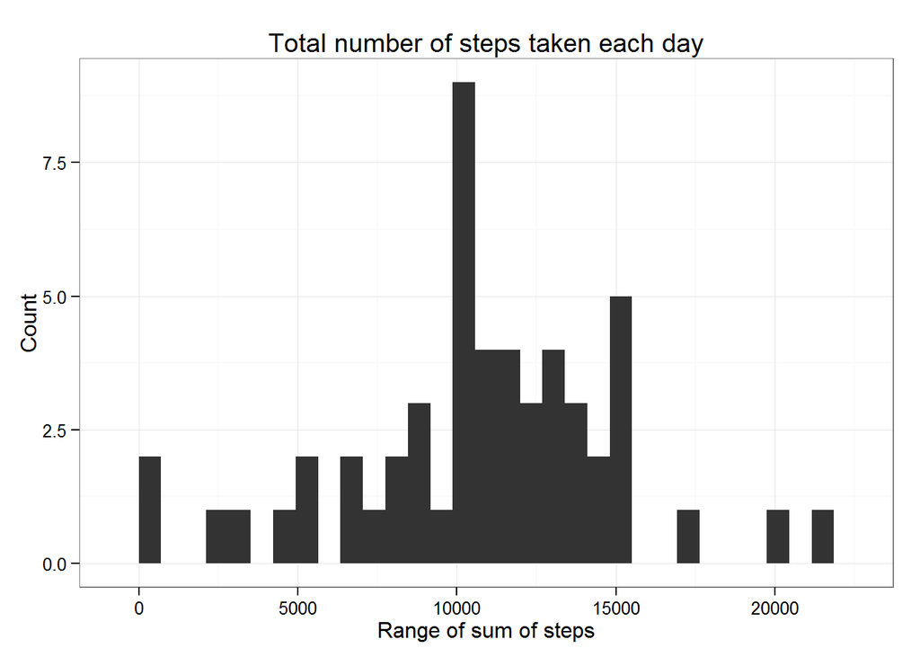

```r
q11 <- aggregate(steps[,1],
             by=list(steps$date),
             FUN=sum)
qplot(x,data=q11,xlab="Range of sum of steps",ylab="Count",
            main="Total number of steps taken each day") +
              theme_bw()
```

3. Calculate and report the mean and median total number of steps taken per day

```r
q12<-mean(q11[,2])
q13<-median(q11[,2])
total<-data.frame(q12,q13)
colnames(total)<-c("mean","median")
total
```

```
##    mean median
## 1 10766  10765
```

It shows the mean total number of steps is 1.0766 × 10<sup>4</sup> and the median is 10765.

### What is the average daily activity pattern?

1. Make a time series plot (i.e. type = “l”) of the 5-minute interval (x-axis) and the average number of steps taken, averaged across all days (y-axis)

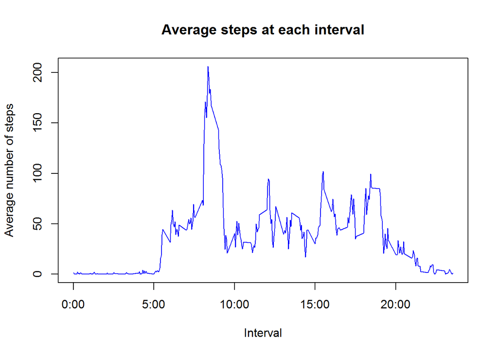

```r
q2<-aggregate(steps[,1],
               by=list(steps$interval),
               FUN=mean)
plot(q2$Group.1,q2$x,type="l",col="blue",xlab="Interval",
               ylab="Average number of steps",
               main="Average steps at each interval",xaxt = "n")
axis(1, labels = c('0:00', '5:00', '10:00', '15:00', '20:00'), at = c(0, 500, 1000, 1500, 2000)) ##Change the label of x-axis into time format
```

2. Which 5-minute interval, on average across all the days in the dataset, contains the maximum number of steps?

```r
maxi<-q2
colnames(maxi)<-c("Interval","Mean of Steps")
maxi<-maxi[maxi[,2]==max(maxi[,2]),]
maxi
```

```
##     Interval Mean of Steps
## 104      835         206.2
```

It shows the maximum number of steps is contained in interval 835 and the number of steps is 206.1698.

### Imputing missing values

Note that there are a number of days/intervals where there are missing values (coded as NA). The presence of missing days may introduce bias into some calculations or summaries of the data.

1. Calculate and report the total number of missing values in the dataset (i.e. the total number of rows with NAs)

```r
na<-subset(raw.data,is.na(raw.data$steps))
nrow(na)
```

```
## [1] 2304
```

2. Devise a strategy for filling in all of the missing values in the dataset.

Here, I use the mean for 5-minte interval to fill in corresponding missing values.

```r
q3<-aggregate(steps[,1],
              by=list(steps$interval),
              FUN=mean)
for (i in 1:2304) {
       for (m in 1:288){
         if (na[i,3]==q3[m,1]) na[i,1]<-q3[m,2]
       }
}
```

3. Create a new dataset that is equal to the original dataset but with the missing data filled in.

```r
steps<-subset(raw.data,!is.na(raw.data$steps))
new.data<-rbind(steps,na)
```

4. Make a histogram of the total number of steps taken each day and calculate and report the mean and median total number of steps taken per day.

```
## stat_bin: binwidth defaulted to range/30. Use 'binwidth = x' to adjust this.
```

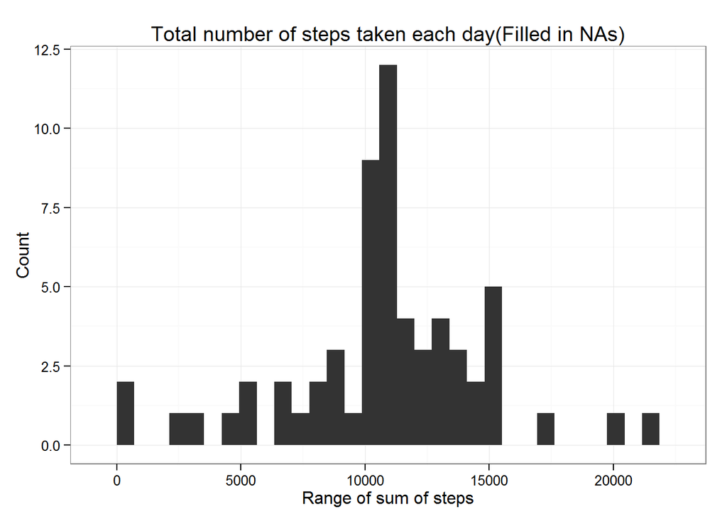

```r
q31 <- aggregate(new.data[,1],
                 by=list(new.data$date),
                 FUN=sum)
qplot(x,data=q31,xlab="Range of sum of steps",ylab="Count",
      main="Total number of steps taken each day(Filled in NAs)")+
      theme_bw()
```

```r
q32<-mean(q31[,2])
q33<-median(q31[,2])
total<-data.frame(q32,q33)
colnames(total)<-c("mean","median")
total
```

```
##    mean median
## 1 10766  10766
```

It shows after filling in NAs, the mean total number of steps is 1.0766 × 10<sup>4</sup> and the median is 1.0766 × 10<sup>4</sup>.

**The results show**:

1). Do these values differ from the estimates from the first part of the assignment?  
* In comparison with the first part of this assignment, the mean and median values do not change dramatically. Only median changes from 10765 to 10766.

2). What is the impact of imputing missing data on the estimates of the total daily number of steps?

```r
##Before filling in missing values
summary(q11)
```

```
##    Group.1                x
##  Length:53          Min.   :   41
##  Class :character   1st Qu.: 8841
##  Mode  :character   Median :10765
##                     Mean   :10766
##                     3rd Qu.:13294
##                     Max.   :21194
```

```r
##After filling in missing values
summary(q31)
```

```
##    Group.1                x
##  Length:61          Min.   :   41
##  Class :character   1st Qu.: 9819
##  Mode  :character   Median :10766
##                     Mean   :10766
##                     3rd Qu.:12811
##                     Max.   :21194
```

- From the results above, we can see the impact of imputing missing data is only obvious on the 1st quantile and 3rd quantile. Also the lenghth of them vary because of the replacement of NA values.